# Module 2 Project - Clustering Algorithms

## Nan Zhao

# 1. Objective of the Proposed Research

The Canadian Government plans to open a new gym in Toronto city. Neighborhoods analysis can help the government to find the best neighborhood as the location of the new gym.  
The objective of this research is to help the Canadian Government show the facts of neighborhoods and recommend the best neighborhood as the location of the gym.  
To achieve this objective, I will use dendrogram, the K-means and KNN algorithms to find the best neighborhood.

The dataset has eight features:

Total population: The population for each neighborhood of Toronto city during 2016.  
number of educated people: The number of educated people per neighborhood.  
number of 15-45: The number of populations aged from 15 to 45.  
number of employers: The number of employers per neighborhood.  
long_latt: The longitudes and latitudes for each neighborhood.  
number of gyms: The number of gyms in each neighborhood.  
number of venues: The number of venues or locations of the past crime scenes in each neighborhood.

# 2. Data Exploration

```python
import numpy as np
import pandas as pd
from pandas import DataFrame

import seaborn as sns
import matplotlib.pyplot as plt
import plotly.express as px

from sklearn.cluster import KMeans
from sklearn.neighbors import KNeighborsClassifier
from scipy.cluster.hierarchy import dendrogram, linkage, leaves_list
```

```python
df0 = pd.read_csv('/Users/nan/1archive-python/Toronto_neighborhood_demographics_geographics_venues.csv')
```

```python
# The following code shows the numbers of rows and columns in the dataset.
```

```python
df0.shape
```

```
(140, 8)
```

```python
# The following is the view of the first ten rows of the dataset:
```

```python
df0.head(10)
```

|  | Neighborhood | Total population | number of educated people | number of 15-45 | number of employers | long_latt | number_gyms | number_venues |
| --- | --- | --- | --- | --- | --- | --- | --- | --- |
| 0 | Agincourt North | 30280.0 | 19805.0 | 11850.0 | 13230.0 | [-79.2816161258827, 43.797405754163] | 0.0 | 26.0 |
| 1 | Agincourt South-Malvern West | 21990.0 | 14535.0 | 8840.0 | 9860.0 | [-79.2891688527481, 43.7851873380096] | 0.0 | 34.0 |
| 2 | Alderwood | 11900.0 | 7915.0 | 4520.0 | 6240.0 | [-79.5532040267975, 43.5954996876866] | 1.0 | 17.0 |
| 3 | Annex | 29180.0 | 23495.0 | 15095.0 | 16770.0 | [-79.4121466573202, 43.6744312990078] | 3.0 | 63.0 |
| 4 | Banbury-Don Mills | 26910.0 | 20555.0 | 9615.0 | 13030.0 | [-79.326504539789, 43.7325704244428] | 2.0 | 14.0 |
| 5 | Bathurst Manor | 15435.0 | 10385.0 | 6115.0 | 7425.0 | [-79.430502667246, 43.7575784301813] | 1.0 | 26.0 |
| 6 | Bay Street Corridor | 19345.0 | 16495.0 | 12800.0 | 10220.0 | [-79.3912583210563, 43.6606532521722] | 1.0 | 96.0 |
| 7 | Bayview Village | 17675.0 | 13960.0 | 7900.0 | 8750.0 | [-79.3834514087178, 43.7640817777541] | 3.0 | 37.0 |
| 8 | Bayview Woods-Steeles | 13535.0 | 10105.0 | 4675.0 | 5935.0 | [-79.3714520973767, 43.8045095069159] | 0.0 | 18.0 |
| 9 | Bedford Park-Nortown | 23185.0 | 16330.0 | 8295.0 | 10945.0 | [-79.4274225674093, 43.7096042496363] | 0.0 | 14.0 |

```python
# The following is the view of the last ten rows of the dataset:
```

```python
df0.tail(10)
```

|  | Neighborhood | Total population | number of educated people | number of 15-45 | number of employers | long_latt | number_gyms | number_venues |
| --- | --- | --- | --- | --- | --- | --- | --- | --- |
| 130 | Willowdale West | 15005.0 | 11950.0 | 6450.0 | 7225.0 | [-79.4137911698636, 43.7729777558747] | 2.0 | 87.0 |
| 131 | Willowridge-Martingrove-Richview | 21345.0 | 14165.0 | 7670.0 | 9355.0 | [-79.5683296239203, 43.6741191022746] | 0.0 | 9.0 |
| 132 | Woburn | 53350.0 | 33590.0 | 22885.0 | 21665.0 | [-79.2183581838386, 43.7490457922858] | 1.0 | 14.0 |
| 133 | Woodbine Corridor | 11705.0 | 8225.0 | 5150.0 | 6440.0 | [-79.3099421226598, 43.6720732368789] | 2.0 | 71.0 |
| 134 | Woodbine-Lumsden | 7825.0 | 5645.0 | 3195.0 | 4060.0 | [-79.3134366327372, 43.6872873462959] | 0.0 | 44.0 |
| 135 | Wychwood | 13985.0 | 8890.0 | 5730.0 | 6700.0 | [-79.4146538367128, 43.6739102281804] | 2.0 | 68.0 |
| 136 | Yonge-Eglinton | 10580.0 | 8515.0 | 4985.0 | 6145.0 | [-79.39764385903482, 43.7033975614873] | 5.0 | 90.0 |
| 137 | Yonge-St.Clair | 11655.0 | 10230.0 | 5145.0 | 7010.0 | [-79.4050120547099, 43.6959787036027] | 2.0 | 41.0 |
| 138 | York University Heights | 27715.0 | 17375.0 | 13615.0 | 12030.0 | [-79.5080896369474, 43.7627147512454] | 0.0 | 21.0 |
| 139 | Yorkdale-Glen Park | 14685.0 | 8000.0 | 5370.0 | 6240.0 | [-79.4706576846475, 43.7253203436703] | 1.0 | 39.0 |

```python
# Remove needless columns.
```

```python
df = df0.drop(['Neighborhood', 'long_latt'], axis=1)
```

```python
# The following code renames column names.

df.columns = ['population','educated','age','employer','gym','venue']

# The following code scales the features in the data set.

df = (df-df.min()) / (df.max()-df.min())

# The following is the view of the first five rows of the dataset.

df.head()
```

|  | population | educated | age | employer | gym | venue |
| --- | --- | --- | --- | --- | --- | --- |
| 0 | 0.507682 | 0.456966 | 0.336370 | 0.365227 | 0.000000 | 0.229167 |
| 1 | 0.330773 | 0.308494 | 0.224433 | 0.247333 | 0.000000 | 0.312500 |
| 2 | 0.115450 | 0.121989 | 0.063778 | 0.120693 | 0.142857 | 0.135417 |
| 3 | 0.484208 | 0.560924 | 0.457047 | 0.489068 | 0.428571 | 0.614583 |
| 4 | 0.435766 | 0.478096 | 0.253254 | 0.358230 | 0.285714 | 0.104167 |

```python
# The following code shows descriptive statistics.
```

```python
df.describe()
```

|  | population | educated | age | employer | gym | venue |
| --- | --- | --- | --- | --- | --- | --- |
| count | 140.000000 | 140.000000 | 140.000000 | 140.000000 | 140.000000 | 140.000000 |
| mean | 0.260071 | 0.259649 | 0.196989 | 0.218973 | 0.130612 | 0.378423 |
| std | 0.194179 | 0.186134 | 0.168910 | 0.162037 | 0.188874 | 0.306016 |
| min | 0.000000 | 0.000000 | 0.000000 | 0.000000 | 0.000000 | 0.000000 |
| 25% | 0.114410 | 0.125863 | 0.083860 | 0.109367 | 0.000000 | 0.145833 |
| 50% | 0.210787 | 0.217073 | 0.149405 | 0.168095 | 0.000000 | 0.244792 |
| 75% | 0.339735 | 0.359699 | 0.263295 | 0.284765 | 0.142857 | 0.575521 |
| max | 1.000000 | 1.000000 | 1.000000 | 1.000000 | 1.000000 | 1.000000 |

# 3. Data Cleaning

```python
# Find which columns have NaN values.
```

```python
df.isnull().any()
```

```
population    False
educated      False
age           False
employer      False
gym           False
venue         False
dtype: bool
```

```python
# Find the sum of duolicated values.
```

```python
df.duplicated().sum()
```

```
0
```

# 4. Adaptation

```python
# Create a new data frame.
```

```python
import copy
df01 = copy.deepcopy(df)
```

```python
# The column of age & educated represents the sum of number of educated and 15-45 years old people.
```

```python
df01['age & educated'] = df01['educated'] + df01['age']
```

```python
# The column of age & educated & emoloyer represents the sum of age & educated & emoloyer.
```

```python
df01['age & educated & emoloyer'] = df01['educated'] + df01['age'] + df01['employer']
```

```python
# The following is the view of the first five rows of the dataset.
```

```python
df01.head()
```

|  | population | educated | age | employer | gym | venue | age & educated | age & educated & emoloyer |
| --- | --- | --- | --- | --- | --- | --- | --- | --- |
| 0 | 0.507682 | 0.456966 | 0.336370 | 0.365227 | 0.000000 | 0.229167 | 0.793336 | 1.158563 |
| 1 | 0.330773 | 0.308494 | 0.224433 | 0.247333 | 0.000000 | 0.312500 | 0.532927 | 0.780260 |
| 2 | 0.115450 | 0.121989 | 0.063778 | 0.120693 | 0.142857 | 0.135417 | 0.185767 | 0.306460 |
| 3 | 0.484208 | 0.560924 | 0.457047 | 0.489068 | 0.428571 | 0.614583 | 1.017971 | 1.507039 |
| 4 | 0.435766 | 0.478096 | 0.253254 | 0.358230 | 0.285714 | 0.104167 | 0.731350 | 1.089579 |

```python
df.head()
```

|  | population | educated | age | employer | gym | venue |
| --- | --- | --- | --- | --- | --- | --- |
| 0 | 0.507682 | 0.456966 | 0.336370 | 0.365227 | 0.000000 | 0.229167 |
| 1 | 0.330773 | 0.308494 | 0.224433 | 0.247333 | 0.000000 | 0.312500 |
| 2 | 0.115450 | 0.121989 | 0.063778 | 0.120693 | 0.142857 | 0.135417 |
| 3 | 0.484208 | 0.560924 | 0.457047 | 0.489068 | 0.428571 | 0.614583 |
| 4 | 0.435766 | 0.478096 | 0.253254 | 0.358230 | 0.285714 | 0.104167 |

# 5. Descriptive Visualization

```python
# The following code shows the top 8 Neighborhoods with most population.

df1 = df0.sort_values(axis = 0, ascending = False, by = ['Total population']).head(8)
df1
```

|  | Neighborhood | Total population | number of educated people | number of 15-45 | number of employers | long_latt | number_gyms | number_venues |
| --- | --- | --- | --- | --- | --- | --- | --- | --- |
| 132 | Woburn | 53350.0 | 33590.0 | 22885.0 | 21665.0 | [-79.2183581838386, 43.7490457922858] | 1.0 | 14.0 |
| 105 | Rouge | 45905.0 | 31355.0 | 19040.0 | 22630.0 | [-79.200181515255, 43.8036974725661] | 1.0 | 20.0 |
| 73 | Malvern | 45085.0 | 28240.0 | 19360.0 | 19425.0 | [-79.2259603274949, 43.7889846980208] | 1.0 | 12.0 |
| 129 | Willowdale East | 45025.0 | 37220.0 | 23425.0 | 22810.0 | [-79.3911674290048, 43.7806330113652] | 0.0 | 4.0 |
| 66 | L'Amoreaux | 44915.0 | 29465.0 | 17720.0 | 19450.0 | [-79.5055865811382, 43.6654755684059] | 0.0 | 19.0 |
| 122 | Waterfront Communities-The Island | 43365.0 | 39080.0 | 29695.0 | 31375.0 | [-79.3546047826462, 43.6549105254359] | 3.0 | 95.0 |
| 58 | Islington-City Centre West | 38070.0 | 28235.0 | 15960.0 | 19735.0 | [-79.541660068977, 43.6150511840077] | 0.0 | 47.0 |
| 33 | Downsview-Roding-CFB | 34650.0 | 19565.0 | 14360.0 | 15800.0 | [-79.5284311615202, 43.7193551775753] | 0.0 | 13.0 |

```python
# Top 8 neighborhoods with most populatio are: Woburn, Rouge, Malvern, Willowdale East, L'Amoreaux, Waterfront Communities-The Island, Islington-City Centre West, and Downsview-Roding-CFB.
```

```python
df1['Neighborhood']
```

```
132                               Woburn
105                                Rouge
73                               Malvern
129                      Willowdale East
66                            L'Amoreaux
122    Waterfront Communities-The Island
58            Islington-City Centre West
33                  Downsview-Roding-CFB
Name: Neighborhood, dtype: object
```

```python
# The following plot shows top 8 Neighborhoods with most population.
```

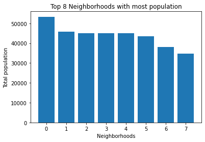

```python
dataX=range(8)
dataY=df1['Total population']
plt.bar(dataX,dataY)
plt.title("Top 8 Neighborhoods with most population")
plt.xlabel("Neighborhoods")
plt.ylabel("Total population")
plt.savefig("1.png")
plt.show()
```

```python
# The following plot shows the number of educated people in the Neighborhoods with most population.
```

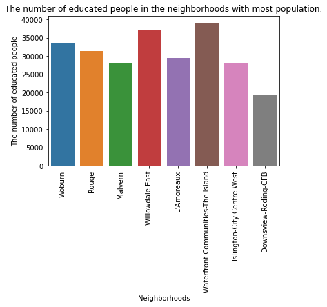

```python
ax1=sns.barplot(x=df1['Neighborhood'], y=df1["number of educated people"].values)
ax1.tick_params(axis="x", rotation=90)
plt.title("The number of educated people in the neighborhoods with most population.")
plt.xlabel("Neighborhoods")
plt.ylabel("The number of educated people")
plt.savefig("2.png")
```

```python
# The following code creates a pie and shows the top 8 Neighborhoods with most population.
```

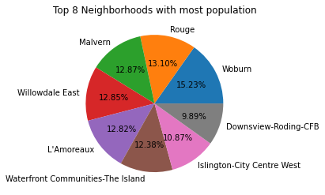

```python
plt.pie(x=df1['Total population'],
        labels=df1['Neighborhood'],
        autopct='%.2f%%')
plt.title("Top 8 Neighborhoods with most population")
plt.savefig("3.png")
plt.show()
```

```python
# The following code creates a boxplot and shows the distribution of different features.
```

```python
df.head()
```

|  | population | educated | age | employer | gym | venue |
| --- | --- | --- | --- | --- | --- | --- |
| 0 | 0.507682 | 0.456966 | 0.336370 | 0.365227 | 0.000000 | 0.229167 |
| 1 | 0.330773 | 0.308494 | 0.224433 | 0.247333 | 0.000000 | 0.312500 |
| 2 | 0.115450 | 0.121989 | 0.063778 | 0.120693 | 0.142857 | 0.135417 |
| 3 | 0.484208 | 0.560924 | 0.457047 | 0.489068 | 0.428571 | 0.614583 |
| 4 | 0.435766 | 0.478096 | 0.253254 | 0.358230 | 0.285714 | 0.104167 |

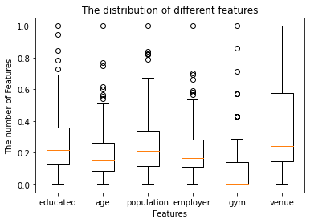

```python
x=df['educated']
y=df['age']
z=df['population']
u=df['employer']
v=df['gym']
w=df['venue']
plt.boxplot((x,y,z,u,v,w), labels=('educated','age','population','employer','gym','venue'))
plt.title("The distribution of different features")
plt.xlabel("Features")
plt.ylabel("The number of Features")
plt.savefig("4.png")
plt.show()
```

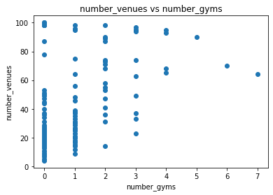

```python
# The following plot shows the relationship between number_venues annd number_gyms.

x=df0['number_gyms']
y=df0['number_venues']
plt.scatter(x,y)
plt.title("number_venues vs number_gyms")
plt.xlabel("number_gyms")
plt.ylabel("number_venues")
plt.savefig("5.png")
plt.show()
```

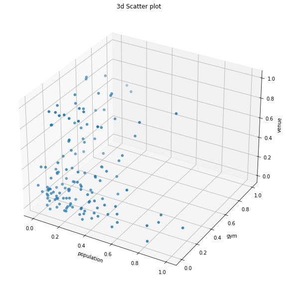

```python
# The following plot shows the relationship between population, gym, and venue.

fig = plt.figure(figsize=(10, 10))
ax = plt.axes(projection='3d')

x = df.population
y = df.gym
z = df.venue

ax.scatter3D(x, y, z)
ax.set_title('3d Scatter plot')
ax.set_xlabel('population')
ax.set_ylabel('gym')
ax.set_zlabel('venue')

plt.savefig("6.png")
plt.show()
```